# Real-time Trading via Interactive Brokers with Package iBrokers2

June 27, 2019

## Implementing a *Hedge Fund in a Box*

- In the past, only large institutional investors had the resources to implement real-time, algorithmic trading.
- The second internet revolution and open-source software have recently given small investors the tools for creating a *Hedge Fund in a Box*, for real-time trading.
- This presentation is a *technical demonstration* of how to implement real-time trading, using the *R* language and Interactive Brokers.
- It will not be about potential market anomalies, nor about promising trading strategies.
- **Disclosure:** I have a personal account with Interactive Brokers. But I do not have any other relationships with Interactive Brokers, and I do not endorse or recommend them.

The *R* Project for Statistical Computing

## Why the *R* Language?

- *R* is widely used for data science and machine learning.
- *R* has a large user base of financial quants.
- *R* provides higher order functions with the ability to *program on the language*.
- Packages [*xts*](https://cran.r-project.org/web/packages/xts/index.html) and [*quantmod*](https://cran.r-project.org/web/packages/quantmod/index.html) for time series.
- Package [*Rcpp*](https://cran.r-project.org/web/packages/Rcpp/index.html) for integrating *C++* code with *R*.
- Package [*shiny*](https://cran.r-project.org/web/packages/shiny/index.html) for interactive plots.
- Package [*iBrokers*](https://cran.r-project.org/web/packages/iBrokers/index.html) for Interactive Brokers.

[figure not shown]

## Executing Real-time Trading Strategies

- Real-time trading requires running a programmatic loop:
  - A trading model is updated with streaming market data aqcuired via an API,
  - The model outputs are fed into an order management system to place trade orders via an API.
- The package [*IBrokers*](https://cran.r-project.org/web/packages/IBrokers/index.html) contains *R* functions for downloading live market data via the [API of Interactive Brokers (IB API)](https://interactivebrokers.github.io/tws-api/), and for placing trade orders to Interactive Brokers.
- The function `iBrokers::reqRealTimeBars()` downloads live (real-time) *OHLC* bars of market data from Interactive Brokers.
- The function `IBrokers::twsOrder()` places trade orders to Interactive Brokers.

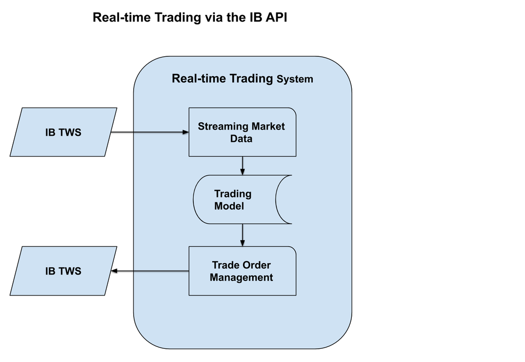

## The Package *IBrokers* for Interactive Brokers

- The package [*IBrokers*](https://cran.r-project.org/web/packages/IBrokers/index.html) allows downloading live market data via the [API of Interactive Brokers (IB API)](https://interactivebrokers.github.io/tws-api/)
- The function `twsConnect()` opens a connection to the *IB API* via the [IB Trader Workstation (TWS)](https://interactivebrokers.github.io/tws-api/initial_setup.html).
- The function `reqRealTimeBars()` downloads live (real-time) *OHLC* bars of market data.
- `reqRealTimeBars()` relies on the functions `eWrapper.RealTimeBars.CSV()` and `twsCALLBACK` to process real-time market events (trades and quotes).
- The function `eWrapper.RealTimeBars.CSV()` creates an *eWrapper* object designed for processing *OHLC* price data.

```r
# Install and load package IBrokers
install.packages("IBrokers")
library(IBrokers)
# Connect to Interactive Brokers TWS via API
ib_connect <- IBrokers::twsConnect(port=7497)
# Define S&P Emini future June 2019 contract
con_tract <- IBrokers::twsFuture(symbol="ES",
  exch="GLOBEX", expiry="201906")
# Get list with instrument information
IBrokers::reqContractDetails(conn=ib_connect,
                             Contract=con_tract)
# Open file connection for data download
file_name <- "C:/Develop/data/ib_data/ES_ohlc_live.csv"
file_connect <- file(file_name, open="w")
# Download live data to file
IBrokers::reqRealTimeBars(conn=ib_connect,
           Contract=con_tract, barSize="1",
           eventWrapper=eWrapper.RealTimeBars.CSV(1),
           file=file_connect)
# Close the Interactive Brokers API connection
IBrokers::twsDisconnect(ib_connect)
# Close data file
close(file_connect)
```

## Market Event Processing Using Package *IBrokers*

- Market events can be either *trade events* or *market quotes*.
- The *OHLC* market data arrives from Interactive Brokers in 5-second intervals.
- Streaming market events are processed in a *callback loop* which runs inside the function `twsCALLBACK()`.
- The function `twsCALLBACK()` first creates an *eWrapper* object by calling the function `eWrapper.RealTimeBars.CSV()`, and then passes it to the function `processMsg()`.
- The function `twsCALLBACK()` then calls `processMsg()` in a *callback loop*.
- The function `processMsg()` processes individual market events by calling the appropriate *eWrapper* *handlers* and saving the data into the *eWrapper* environment.

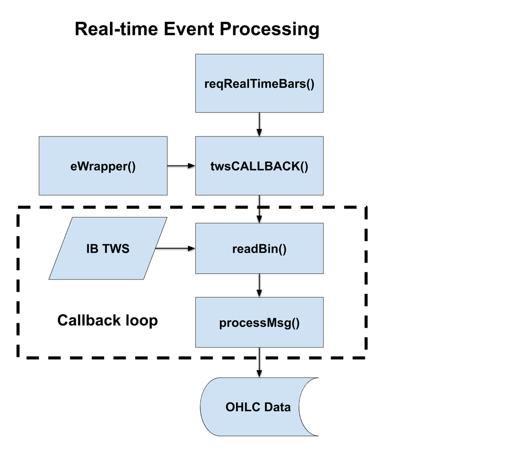

## Trade Processing Using Package *IBrokers2*

- The trade processing framework is similar to that for downloading real-time *OHLC* market data using `reqRealTimeBars()`.
- The main difference is the `trade_wrapper()` function, which creates a *trade wrapper* environment, containing the data handler `realtimeBars()` and the trading model `model_function()`.
- The function `trade_realtime()` first calls `trade_wrapper()` to create a *trade wrapper* environment, and then calls `call_back()` to run a *callback loop*.
- `call_back()` calls the `processMsg()` in a *callback loop*, which calls the *handler* `realtimeBars()`.
- The function `realtimeBars()` updates the *trade wrapper* environment with new data and then runs the trading model `model_function()`.

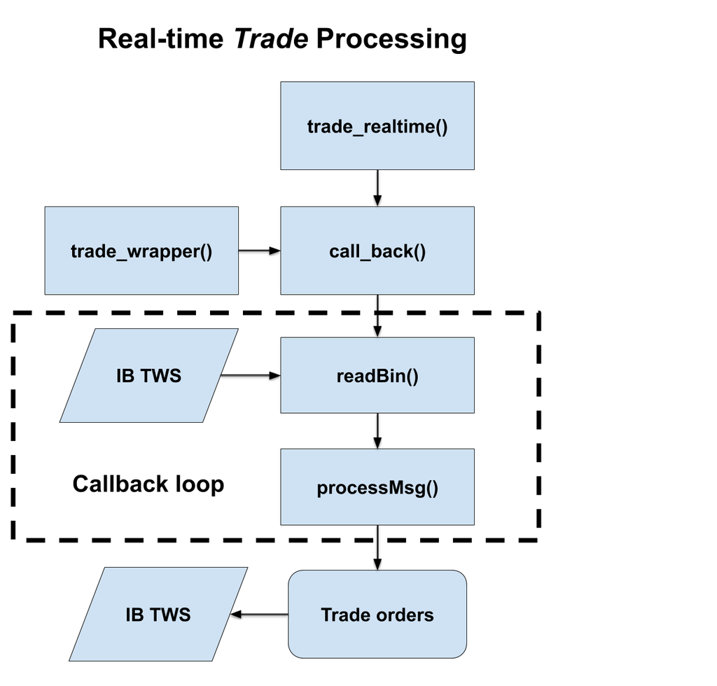

## Defining Contracts and Trading Parameters

- The instrument parameters specify the contract or security, the exchange, etc.
- The trading instruments and their parameters are specified as lists to allow trading multiple instruments simultaneously.
- The list of trading parameters contains the name of the trading model function, and a vector of its parameters.
- The function `model_function()` is the trading model function, which reruns the trading model and places trade orders using `IBrokers2::twsOrder()`.

```r
# Install and load package IBrokers2
devtools::install_github(repo="algoquant/IBrokers2")
library(IBrokers2)

# Define instrument for trading ES futures contracts
con_tracts <- list(
  ES=IBrokers2::twsFuture(
    symbol="ES",
    exch="GLOBEX",
    expiry="201906"))

# Define parameters of market making strategy
trade_params <- list(ES=list(
  model_function="make_markets",
  model_params=c(buy_spread=0.25,
                 sell_spread=0.25,
                 siz_e=1,
                 pos_limit=10,
                 lagg=2,
                 lamb_da=0.05)))
```

## The Trading Model Function

- Users can define their own custom trading model function inside the `trade_wrapper()` function.
- We can define a simple market-making strategy as follows:
  - Place a limit *buy* order at previous bar *Low* price minus *buy spread*,
  - Place a limit *sell* order at previous bar *High* price plus *sell spread*.
- The function `make_markets()` is the trading model function, which reruns the market-making model and places limit trade orders using `twsOrder()`.
- The function `make_markets()` first cancels the previous trade orders.

```r
### The function make_markets() performs a market making strategy
make_markets <- function(contract_id, trade_params, ib_connect) {
  ## Extract bars of prices from da_ta$bar_data
  count_er <- e_wrapper$da_ta$count_er[contract_id]
  bar_new <- e_wrapper$da_ta$bar_data[[contract_id]][count_er, ]
  bar_lag <- e_wrapper$da_ta$bar_data[[contract_id]][count_er - trade_params["lagg"], ]
  ## Calculate the trade limit prices
  buy_limit <- (bar_lag[4] - trade_params["buy_spread"])
  sell_limit <- (bar_lag[3] + trade_params["sell_spread"])
  # buy_limit should be no greater than close price
  clo_se <- bar_new[5]
  buy_limit <- min(clo_se, buy_limit)
  # sell_limit should be no less than close price
  sell_limit <- max(clo_se, sell_limit)

  ## Cancel previous limit orders
  if (IBrokers2::is.twsConnection(ib_connect)) {
    buy_id <- e_wrapper$da_ta$trade_ids[contract_id, "buy_id"]
    if (!is.na(buy_id))
      IBrokers2::cancelOrder(ib_connect, buy_id)
    sell_id <- e_wrapper$da_ta$trade_ids[contract_id, "sell_id"]
    if (!is.na(sell_id))
      IBrokers2::cancelOrder(ib_connect, sell_id)
  }  # end if
```

## Placing Limit Trade Orders

- The *trade wrapper* environment maintains data about the state of the trading environment, such as trade IDs, positions, etc.
- New limit orders are placed only if the current position doesn’t exceed the limit.

```r
## Place new limit orders
if (IBrokers2::is.twsConnection(ib_connect)) {
  posi_tion <- e_wrapper$da_ta$portfolio[contract_id, "position"]
  # Place buy limit order only if position doesn't exceed limit
  if (posi_tion < trade_params["pos_limit"]) {
    buy_id <- IBrokers2::reqIds(ib_connect)
    buy_order <- IBrokers2::twsOrder(
      buy_id, orderType="LMT",
      lmtPrice=buy_limit, action="BUY",
      totalQuantity=trade_params["siz_e"])
    IBrokers2::placeOrder(ib_connect, e_wrapper$da_ta$con_tracts[[contract_id]], buy_order)
    e_wrapper$da_ta$trade_ids[contract_id, "buy_id"] <<- buy_id
  }  # end if
  # Place sell limit order only if position doesn't exceed limit
  if (posi_tion > -trade_params["pos_limit"]) {
    sell_id <- IBrokers2::reqIds(ib_connect)
    sell_order <- IBrokers2::twsOrder(
      sell_id, orderType="LMT",
      lmtPrice=sell_limit, action="SELL",
      totalQuantity=trade_params["siz_e"])
    IBrokers2::placeOrder(ib_connect, e_wrapper$da_ta$con_tracts[[contract_id]], sell_order)
    e_wrapper$da_ta$trade_ids[contract_id, "sell_id"] <<- sell_id
  }  # end if
}  # end if
invisible(list(buy_limit=buy_limit, sell_limit=sell_limit))
}  # end make_markets
```

## Real-time Trading Using Package *IBrokers2*

- The function `trade_realtime()` first calls `trade_wrapper()` to create a *trade wrapper* environment, and then calls `call_back()` to run a *callback loop*.
- Every time new data arrives, `model_function()` reruns the trading model and places trade orders using `IBrokers2::twsOrder()`.
- Most of the code changes needed to implement a new trading strategy occur in the functions `trade_wrapper()`, the data handler `realtimeBars()`, and the trading model `model_function()`.

```r
# Open file connection for data download
file_names <- "C:/Develop/data/ib_data/ES_ohlc_live.csv"
file_connects <- lapply(file_names,
  function(file_name) file(file_name, open="w"))
# Open the IB connection to TWS
ac_count <- "DU1851021"
ib_connect <- IBrokers2::twsConnect(port=7497)
# Run the trading model (strategy):
IBrokers2::trade_realtime(
  ib_connect=ib_connect,
  Contract=con_tracts,
  eventWrapper=IBrokers2::trade_wrapper(
    ac_count=ac_count,
    con_tracts=con_tracts,
    trade_params=trade_params,
    file_connects=file_connects,
    warm_up=10),
  CALLBACK=IBrokers2::call_back,
  file=file_connects)
# Stop the trading loop by hitting the red STOP button in RStudio
# Close the Interactive Brokers API connection
IBrokers2::twsDisconnect(ib_connect)
# Close data files
for (file_connect in file_connects) close(file_connect)
```

## The *EWMA* Crossover Strategy

- The Exponentially Weighted Moving Average price (*EWMA*) is equal to the average of prices weighted by a decay parameter \(\lambda\).
- The parameter \(\lambda\) determines the rate of decay of the exponential weights, with smaller values of \(\lambda\) producing faster decay, giving more weight to recent prices, and vice versa.

```r
# Define instrument for trading ES futures contracts
con_tracts <- list(
  ES=IBrokers2::twsFuture(
    symbol="ES",
    exch="GLOBEX",
    expiry="201906"))

# Define parameters of EWMA crossover strategy
trade_params <- list(ES=list(
  model_function="crossover_strat",
  model_params=c(is_contrarian=TRUE,
                 siz_e=2,
                 lamb_da=0.2)))
```

## The Crossover Strategy Model Function

- The function `crossover_strat()` is the trading model function for a crossover strategy.

```r
### The function crossover_strat() performs an EWMA crossover strategy
crossover_strat <- function(contract_id, trade_params, ib_connect) {
  ## Extract bars of prices from da_ta$bar_data
  count_er <- e_wrapper$da_ta$count_er[contract_id]
  bar_new <- e_wrapper$da_ta$bar_data[[contract_id]][count_er, ]
  ew_ma <- e_wrapper$da_ta$ewma[contract_id]
  w_ap <- bar_new[7]
  posi_tion <- e_wrapper$da_ta$portfolio[contract_id, "position"]
  is_contrarian <- trade_params["is_contrarian"]
```

## Placing Market Trade Orders

- We can define a simple contrarian *EWMA* crossover strategy as follows:
  - Place a market *sell* order when the current price crosses above the *EWMA*,
  - Place a market *buy* order when the current price crosses below the *EWMA*.
- Market orders are placed immediately after the *EWMA* price crosses the current price.
- The *trade wrapper* environment maintains data about the state of the trading environment, such as trade IDs, positions, etc.

```r
## Place market orders
if (IBrokers2::is.twsConnection(ib_connect)) {
  if (is_contrarian) {
    if ((w_ap > ew_ma) & (posi_tion > 0)) {
      # Place buy market order
      order_id <- IBrokers2::reqIds(ib_connect)
      ib_order <- IBrokers2::twsOrder(
        order_id, orderType="MKT", action="SELL",
        totalQuantity=trade_params["siz_e"])
      IBrokers2::placeOrder(
        ib_connect, e_wrapper$da_ta$con_tracts[[contract_id]], ib_order)
    } else if ((w_ap < ew_ma) & (posi_tion < 0)) {
      # Place sell market order
      order_id <- IBrokers2::reqIds(ib_connect)
      ib_order <- IBrokers2::twsOrder(
        order_id, orderType="MKT", action="BUY",
        totalQuantity=trade_params["siz_e"])
      IBrokers2::placeOrder(
        ib_connect, e_wrapper$da_ta$con_tracts[[contract_id]], ib_order)
    }  # end if
  } else {
    if ((w_ap > ew_ma) & (posi_tion < 0)) {
      # Place buy market order
      order_id <- IBrokers2::reqIds(ib_connect)
      ib_order <- IBrokers2::twsOrder(order_id, orderType="MKT", action="BUY", totalQuantity=trade_params["siz_e"])
      IBrokers2::placeOrder(ib_connect, e_wrapper$da_ta$con_tracts[[contract_id]], ib_order)
    } else if ((w_ap < ew_ma) & (posi_tion > 0)) {
      # Place sell market order
      order_id <- IBrokers2::reqIds(ib_connect)
      ib_order <- IBrokers2::twsOrder(order_id, orderType="MKT", action="SELL", totalQuantity=trade_params["siz_e"])
      IBrokers2::placeOrder(ib_connect, e_wrapper$da_ta$con_tracts[[contract_id]], ib_order)
    }  # end if
  }  # end if is_contrarian
}  # end if
invisible(list(WAP=w_ap, EWMA=ew_ma))
}  # end crossover_strat
```

## Running the *EWMA* Crossover Strategy

- The *EWMA* crossover strategy is run by calling the function `trade_realtime()`, in the same way as for other strategies.
- The function `trade_realtime()` first calls `trade_wrapper()` to create a *trade wrapper* environment, and then calls `call_back()` to run a *callback loop*.
- Every time new data arrives, `model_function()` reruns the trading model and places trade orders using `IBrokers2::twsOrder()`.
- Most of the code changes needed to implement a new trading strategy occur in the functions `trade_wrapper()`, the data handler `realtimeBars()`, and the trading model `model_function()`.

```r
# Open file connection for data download
file_names <- "C:/Develop/data/ib_data/ES_ohlc_live.csv"
file_connects <- lapply(file_names,
  function(file_name) file(file_name, open="w"))
# Open the IB connection to TWS
ac_count <- "DU1851021"
ib_connect <- IBrokers2::twsConnect(port=7497)
# Run the trading model (strategy):
IBrokers2::trade_realtime(
  ib_connect=ib_connect,
  Contract=con_tracts,
  eventWrapper=IBrokers2::trade_wrapper(
    ac_count=ac_count,
    con_tracts=con_tracts,
    trade_params=trade_params,
    file_connects=file_connects,
    warm_up=10),
  CALLBACK=IBrokers2::call_back,
  file=file_connects)
# Stop the trading loop by hitting the red STOP button in RStudio
# Close the Interactive Brokers API connection
IBrokers2::twsDisconnect(ib_connect)
# Close data files
for (file_connect in file_connects) close(file_connect)
```

## The Pairs Trading Strategy

- In the pairs trading strategy, a regression of the prices is performed, over a rolling look-back window.
- The parameter *look_back* is the number of data points in the look-back window.
- The parameter *thresh_old* is the threshold at which a trade is triggered.
- The parameter *siz_e* is the fixed number of shares of the first stock.

```r
# Define instruments for trading two stocks: GOOG and AAPL
sym_bols <- c("GOOG", "AAPL")
con_tracts <- lapply(sym_bols,
  IBrokers2::twsEquity, primary="SMART")
names(con_tracts) <- sym_bols

# Define parameters for pairs trading two stocks: GOOG and AAPL
trade_params <- list(
  GOOG=list(
    model_function="pairs_strat",
    model_params=c(
      is_contrarian=TRUE,
      siz_e=100,
      look_back=50,
      thresh_old=1.0,
      lamb_da=0.2)),
  AAPL=NULL)
```

## The Pairs Trading Strategy Model Function

- The function `pairs_strat()` is the trading model function for a pairs trading strategy.
- In the pairs trading strategy, a regression of the prices is performed, over a rolling look-back window.
- The regression can be performed very efficiently in *C++* using the package [*Rcpp*](https://cran.r-project.org/web/packages/Rcpp/index.html) for integrating *C++* code with *R*.
- The residual of the regression determines the trade decision.

```r
  ### The function pairs_strat() performs a pairs trading strategy
  pairs_strat <- function(contract_id, trade_params, ib_connect) {
    look_back <- trade_params["look_back"]
    thresh_old <- trade_params["thresh_old"]
    posi_tion <- e_wrapper$da_ta$portfolio[contract_id, "position"]
    siz_e <- trade_params["siz_e"]
    is_contrarian <- trade_params["is_contrarian"]
    ## Extract bars of prices from da_ta$bar_data
    count_er <- e_wrapper$da_ta$count_er[contract_id]
    bar_new <- e_wrapper$da_ta$bar_data[[contract_id]][((count_er-look_back+1):count_er), ]
    bar_ref <- e_wrapper$da_ta$bar_data[[2]][((count_er-look_back+1):count_er), ]
    ## Perform regression in C++
    de_sign <- cbind(bar_new[, 7], bar_ref[, 7])
    de_sign <- na.omit(de_sign)
    colnames(de_sign) <- e_wrapper$da_ta$name_s
    l_m <- HighFreq::calc_lm(de_sign[, 1], de_sign[, 2, drop=FALSE])
    co_eff <- l_m$coefficients[2, 1]
    z_score <- l_m$z_score
    ## Write to console
    ew_ma <- e_wrapper$da_ta$ewma[contract_id]
    w_ap <- bar_new[NROW(bar_new), 7]
    cat("technical data: \t", paste0("coeff=", round(co_eff, 2)), paste0("z-score=", round(z_score, 2)), "\n")
```

## Placing Market Trade Orders

- We can define a simple contrarian pairs trading strategy as follows:
  - Place a market pairs *sell* order when the residual is above the trade threshold,
  - Place a market pairs *buy* order when the residual is below the trade threshold.
- The *trade wrapper* environment maintains data about the state of the trading environment, such as trade IDs, positions, etc.

```r
## Place market orders
if (IBrokers2::is.twsConnection(ib_connect)) {
  n_shares <- round(co_eff*siz_e)
  if (is_contrarian) {
    if (!is.na(z_score) && (z_score > thresh_old) && (posi_tion > 0)) {
      # Place buy market order
      order_id <- IBrokers2::reqIds(ib_connect)
      ib_order <- IBrokers2::twsOrder(
        order_id, orderType="MKT", action="SELL",
        totalQuantity=siz_e)
      IBrokers2::placeOrder(ib_connect, e_wrapper$da_ta$con_tracts[[contract_id]], ib_order)
      order_id <- IBrokers2::reqIds(ib_connect)
      ib_order <- IBrokers2::twsOrder(
        order_id, orderType="MKT", action="BUY",
        totalQuantity=n_shares)
      IBrokers2::placeOrder(ib_connect, e_wrapper$da_ta$con_tracts[[2]], ib_order)
    } else if (!is.na(z_score) && (z_score < -thresh_old) && (posi_tion < 0)) {
      # Place sell market order
      order_id <- IBrokers2::reqIds(ib_connect)
      ib_order <- IBrokers2::twsOrder(order_id, orderType="MKT", action="BUY", totalQuantity=siz_e)
      IBrokers2::placeOrder(ib_connect, e_wrapper$da_ta$con_tracts[[contract_id]], ib_order)
      order_id <- IBrokers2::reqIds(ib_connect)
      ib_order <- IBrokers2::twsOrder(order_id, orderType="MKT", action="SELL", totalQuantity=n_shares)
      IBrokers2::placeOrder(ib_connect, e_wrapper$da_ta$con_tracts[[2]], ib_order)
    }  # end if
  } else {
    if (!is.na(z_score) && (z_score > thresh_old) && (posi_tion > 0)) {
      # Place buy market order
      order_id <- IBrokers2::reqIds(ib_connect)
      ib_order <- IBrokers2::twsOrder(order_id, orderType="MKT", action="BUY", totalQuantity=siz_e)
      IBrokers2::placeOrder(ib_connect, e_wrapper$da_ta$con_tracts[[contract_id]], ib_order)
      order_id <- IBrokers2::reqIds(ib_connect)
      ib_order <- IBrokers2::twsOrder(order_id, orderType="MKT", action="SELL", totalQuantity=n_shares)
      IBrokers2::placeOrder(ib_connect, e_wrapper$da_ta$con_tracts[[2]], ib_order)
    } else if (!is.na(z_score) && (z_score < -thresh_old) && (posi_tion < 0)) {
      # Place sell market order
      order_id <- IBrokers2::reqIds(ib_connect)
      ib_order <- IBrokers2::twsOrder(order_id, orderType="MKT", action="SELL", totalQuantity=siz_e)
      IBrokers2::placeOrder(ib_connect, e_wrapper$da_ta$con_tracts[[contract_id]], ib_order)
      order_id <- IBrokers2::reqIds(ib_connect)
      ib_order <- IBrokers2::twsOrder(order_id, orderType="MKT", action="BUY", totalQuantity=n_shares)
      IBrokers2::placeOrder(ib_connect, e_wrapper$da_ta$con_tracts[[2]], ib_order)
    }  # end if
  }  # end if is_contrarian
}  # end if
invisible(list(co_eff=co_eff, z_score=z_score))
}  # end pairs_strat
```

## Running the Pairs Trading Strategy

- The pairs trading strategy is run by calling the function `trade_realtime()`, in the same way as for other strategies.
- The function `trade_realtime()` first calls `trade_wrapper()` to create a *trade wrapper* environment, and then calls `call_back()` to run a *callback loop*.
- Every time new data arrives, `model_function()` reruns the trading model and places trade orders using `IBrokers2::twsOrder()`.
- Most of the code changes needed to implement a new trading strategy occur in the functions `trade_wrapper()`, the data handler `realtimeBars()`, and the trading model `model_function()`.

```r
# Open file connection for data download
data_dir <- "C:/Develop/data/ib_data"
file_names <- file.path(data_dir,
  paste0(names(con_tracts), "_", format(Sys.time(), format="%m_%d_%Y_%H_%M"), ".csv"))
file_connects <- lapply(file_names,
  function(file_name) file(file_name, open="w"))
# Open the IB connection to TWS
ac_count <- "DU1851021"
ib_connect <- IBrokers2::twsConnect(port=7497)
# Run the trading model (strategy):
IBrokers2::trade_realtime(
  ib_connect=ib_connect,
  Contract=con_tracts,
  eventWrapper=IBrokers2::trade_wrapper(
    ac_count=ac_count,
    con_tracts=con_tracts,
    trade_params=trade_params,
    file_connects=file_connects,
    warm_up=10),
  CALLBACK=IBrokers2::call_back,
  file=file_connects)
# Stop the trading loop by hitting the red STOP button in RStudio
# Close the Interactive Brokers API connection
IBrokers2::twsDisconnect(ib_connect)
# Close data files
for (file_connect in file_connects) close(file_connect)
```

## The *eWrapper* Object

- An *eWrapper* object consists of a *data environment* and *handlers* (methods) for formatting and adding new data to the *data environment*.
- The function `eWrapper()` creates a generic *eWrapper* object.
- The function `eWrapper.RealTimeBars.CSV()` creates an *eWrapper* object designed for processing *OHLC* price data.
- The functionality of package *IBrokers* can easily be extended by writing new *eWrapper* objects, designed for processing different types of data and performing different tasks.

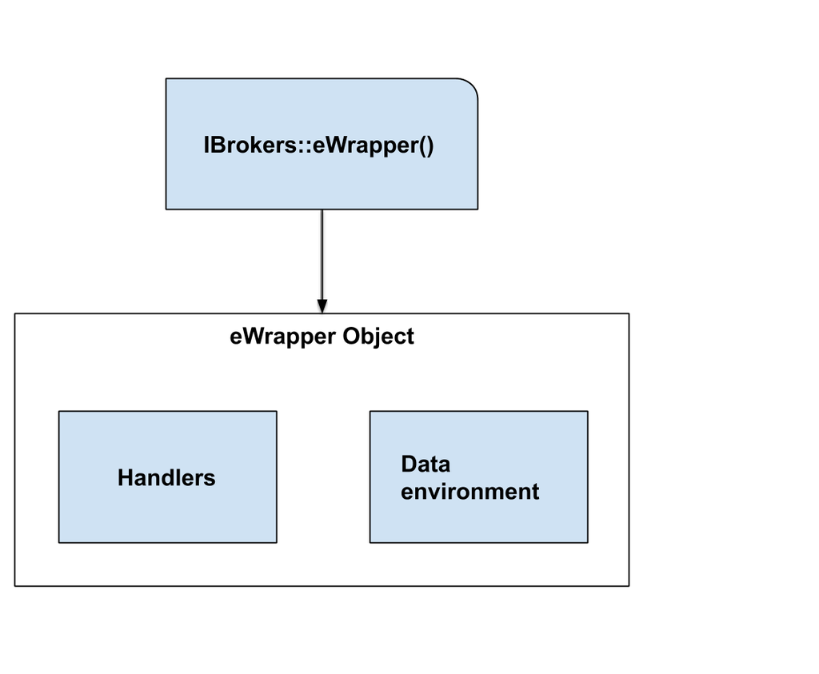

## The *Trade Wrapper* Environment

- The functionality of package *IBrokers* can easily be extended to trading by writing a new *eWrapper* object.
- The function `IBrokers2::trade_wrapper()` creates a *trade wrapper* environment (a modified *eWrapper*) designed for real-time trading.
- The *trade wrapper* data environment contains buffers for *OHLC* market data, trading model parameters, instrument positions, open trade orders, etc.
- The *trade wrapper* contains the data handler `realtimeBars()` and the trading model `model_function()`.
- The function `IBrokers2::trade_wrapper()` can be modified to support different market instruments and trading models.

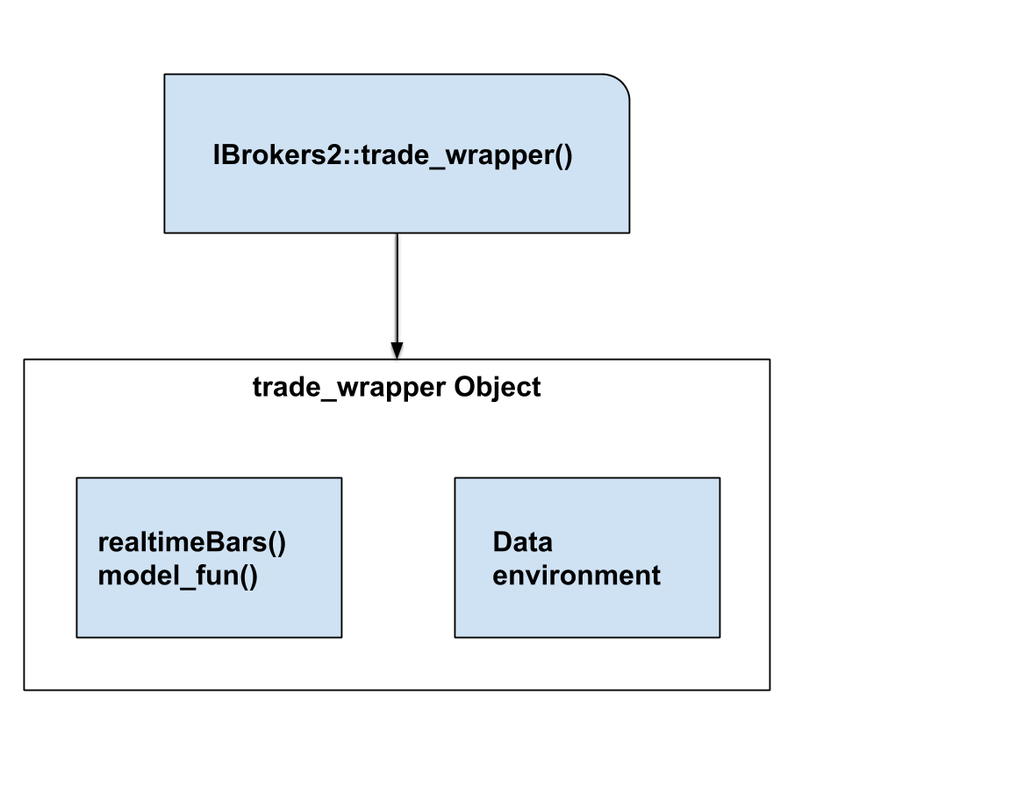

## Functions in Package *IBrokers2*

- Most of the functions in package *IBrokers2* were derived from those in *IBrokers*.
- `IBrokers2::trade_realtime()` initiates real-time trading.
- `IBrokers2::trade_wrapper()` creates a *trade wrapper* environment, containing the data handler `realtimeBars()` and the trading model `model_function()`.
- The function `realtimeBars()` is a *trade wrapper* handler which updates the data environment with new data and then runs the trading model `model_function()`.
- `model_function()` reruns the trading model using updated market data, and places trade orders using `IBrokers2::twsOrder()`.
- The function `IBrokers2::call_back()` performs the *callback loop*.

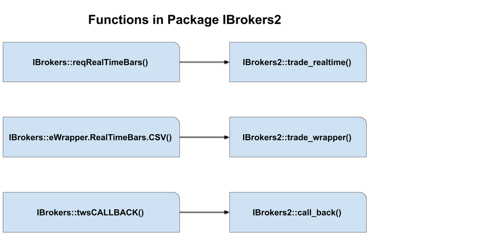

## Future Development of Package *IBrokers2*

### Current state

- The package *IBrokers2* is currently an initial proof of concept, rather than a working application.
- The package *IBrokers2* is derived from the package *IBrokers*, and is fully backward compatible with it.
- All the *IBrokers* functions and variables are preserved exactly in *IBrokers2*, while some additional functions have been added to provide functionality for real-time trading.

### Future development

- Rewrite critical functions using *Rcpp* and the C++ API of Interactive Brokers.

### Applications

- Education and trading competitions: Interactive Brokers has been kind to provide student *paper trading* accounts, together with market data.
- Crowd-sourced hedge fund: the package *IBrokers2* could become the foundation for a system similar to [*Quantopian*](https://www.quantopian.com/).

### Disclaimer

- This software comes with no warranty and should not be used in live trading with real capital at risk. This software is not affiliated or endorsed by Interactive Brokers.

## Thank You

- Many thanks to Jeff Ryan for developing the package *IBrokers*.
- The package *IBrokers2* is available on GitHub:  
  https://github.com/algoquant/iBrokers2

### Contact information

NYU email: jp3900@nyu.edu

LinkedIn profile:  
https://www.linkedin.com/in/jerzypawlowski